# Introduction to Speech Processing

**Objectives:**

- Audio signal IO
- Calculating spectrum and spectrogram of speech sounds
- Speech processing using librosa and pydub

## 1. Audio signal IO

We will be mainly using pydub for speech signal IO and librosa for speech signal processing. Documentation for librosa can be found at https://librosa.org/doc/latest/index.html. In this section, we will learn how to read/write audio signals from files.

```python
import numpy as np
import matplotlib.pyplot as plt
import librosa
import librosa.display
import IPython.display as ipd

from pydub import AudioSegment
from pydub.utils import mediainfo

speech = AudioSegment.from_wav('arctic_a0005.wav') # Read audio data from file
x = speech.get_array_of_samples() # samples x(t)
x_sr = speech.frame_rate # sampling rate f

print('Sampling rate: ', x_sr)
print('Number of samples: ', len(x))
```

```
Sampling rate:  16000
Number of samples:  22640
```

### To understand the number of samples in x, you can get the duration of arctic_a0005.wav (in seconds) and multiply this duration by the sampling rate as follows:

```python
duration = librosa.get_duration(filename = 'arctic_a0005.wav')
n_samples = duration * x_sr

print('duration: ', duration)
print('n_samples: ', n_samples)
```

```
duration:  1.415
n_samples:  22640.0
```

### We can visualise the signal x in time domain using the following code:

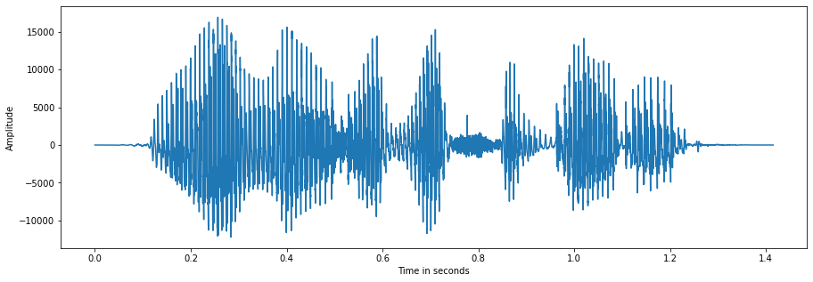

```python
x_range = np.linspace(0, duration, len(x))

plt.figure(figsize = (15, 5))
plt.plot(x_range, x)
plt.xlabel('Time in seconds')
plt.ylabel('Amplitude')
```

Now, suppose that we want to divide the signal x into two equal parts, named x1 and x2, i.e., each part has 11320 samples. We then store those parts into .wav files.

**To save audio data to .wav files, you can pydub as follows:**

```python
mid_point = int(len(x) / 2)
x1 = x[0:mid_point]
x2 = x[mid_point:len(x)]

x1_audio = AudioSegment(
    #raw data
    data = x1,

    #2 bytes = 16 bit samples
    sample_width = 2,

    #frame rate
    frame_rate = x_sr,

    #channels = 1 for mono and 2 for stereo
    channels = 1)

x2_audio = AudioSegment(
    #raw data
    data = x2,

    #2 bytes = 16 bit samples
    sample_width = 2,

    #frame rate
    frame_rate = x_sr,

    #channels = 1 for mono and 2 for stereo
    channels = 1)

x1_audio.export('arctic_a0005_1.wav', format = 'wav')
x2_audio.export('arctic_a0005_2.wav', format = 'wav')
```

```
<_io.BufferedRandom name='arctic_a0005_2.wav'>
```

### We can visualise the signal x1 in time domain using the following code:

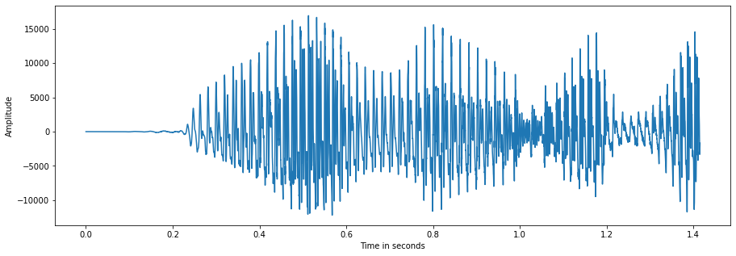

```python
x1_range = np.linspace(0, duration, len(x1))

plt.figure(figsize = (15, 5))
plt.plot(x1_range, x1)
plt.xlabel('Time in seconds')
plt.ylabel('Amplitude')
```

### We can visualise the signal x2 in time domain using the following code:

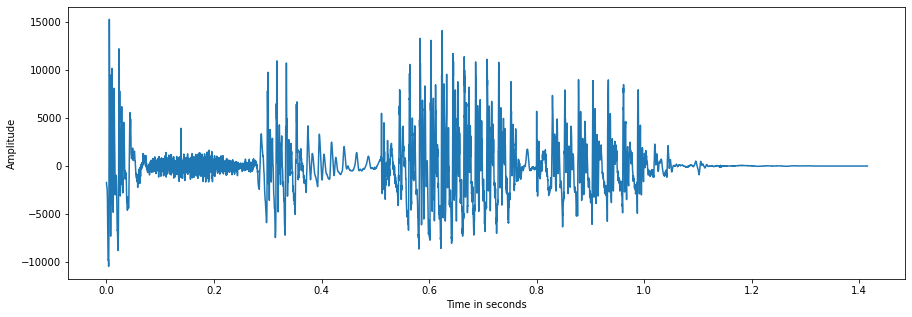

```python
x2_range = np.linspace(0, duration, len(x2))

plt.figure(figsize = (15, 5))
plt.plot(x2_range, x2)
plt.xlabel('Time in seconds')
plt.ylabel('Amplitude')
```

## 2. Fourier Transform

In this section, we will apply the Fourier transform on audio signals to compute the spectrograms of the signals. In practice, we do not calculate the Fourier transform of a signal on its entire time domain but only on short temporal segments. These temporal segments are called frames and detected using windowing techniques. Two consecutive frames can have some overlapping.

### To calculate the Fourier transfrom of x, you need to determine the range of frequencies of interest and call the method librosa.stft as follows:

```python
#range of frequencies of interest for speech signal.
#It can be any positive value, but should be a power of 2
freq_range = 1024

#window size: the number of samples per frame
#each frame is of 30ms
win_length = int(x_sr * 0.03)

#number of samples between tww consecutive frames
hop_length = int(win_length / 2)

#windowing technique
window = 'hann'

#bydefault, hop_length = win_length / 4
X = librosa.stft(np.float32(x),
                 n_fft = freq_range,
                 window = window,
                 hop_length = hop_length,
                 win_length = win_length)
```

librosa.stft returns an array, e.g., X. This array includes freq_range/2+1 rows corresponding to the frequencies in [0, freq_range/2].

```python
print(X.shape)
```

```
(513, 95)
```

```python
n_samples / hop_length
```

```
94.33333333333333
```

### X actually contains the spectrogram of x. To visualise X, we can perfrom:

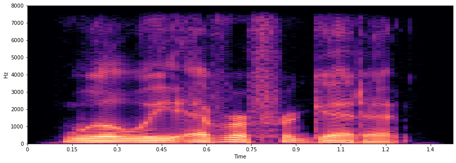

```python
plt.figure(figsize = (15, 5))

#convert the amplitude to decibels, just for illustration purpose
Xdb = librosa.amplitude_to_db(abs(X))
librosa.display.specshow(
    #spectrogram
    Xdb,

    #sampling rate
    sr = x_sr,

    #label for horizontal axis
    x_axis = 'time',

    #presentation scale
    y_axis = 'linear',

    #hop_length
    hop_length = hop_length)
```

### Creating spectrograms for x1

```python
#range of frequencies of interest for speech signal.
#It can be any positive value, but should be a power of 2
freq_range = 1024

#window size: the number of samples per frame
#each frame is of 30ms
win_length = int(x_sr * 0.03)

#number of samples between tww consecutive frames
hop_length = int(win_length / 2)

#windowing technique
window = 'hann'

#bydefault, hop_length = win_length / 4
X1 = librosa.stft(np.float32(x1),
                 n_fft = freq_range,
                 window = window,
                 hop_length = hop_length,
                 win_length = win_length)
```

```python
print(X1.shape)
```

```
(513, 48)
```

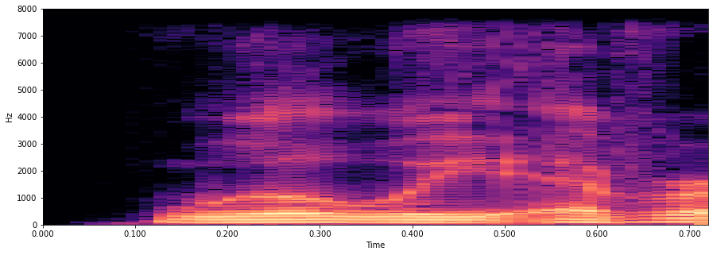

```python
plt.figure(figsize = (15, 5))

#convert the amplitude to decibels, just for illustration purpose
X1db = librosa.amplitude_to_db(abs(X1))
librosa.display.specshow(
    #spectrogram
    X1db,

    #sampling rate
    sr = x_sr,

    #label for horizontal axis
    x_axis = 'time',

    #presentation scale
    y_axis = 'linear',

    #hop_length
    hop_length = hop_length)

plt.savefig('X1Spectogram.png')
```

### Creating spectrograms for x2

```python
#range of frequencies of interest for speech signal.
#It can be any positive value, but should be a power of 2
freq_range = 1024

#window size: the number of samples per frame
#each frame is of 30ms
win_length = int(x_sr * 0.03)

#number of samples between tww consecutive frames
hop_length = int(win_length / 2)

#windowing technique
window = 'hann'

#bydefault, hop_length = win_length / 4
X2 = librosa.stft(np.float32(x2),
                 n_fft = freq_range,
                 window = window,
                 hop_length = hop_length,
                 win_length = win_length)
```

```python
print(X2.shape)
```

```
(513, 48)
```

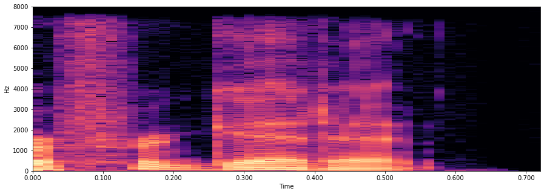

```python
plt.figure(figsize = (15, 5))

#convert the amplitude to decibels, just for illustration purpose
X2db = librosa.amplitude_to_db(abs(X2))
librosa.display.specshow(
    #spectrogram
    X2db,

    #sampling rate
    sr = x_sr,

    #label for horizontal axis
    x_axis = 'time',

    #presentation scale
    y_axis = 'linear',

    #hop_length
    hop_length = hop_length)

plt.savefig('X2Spectogram.png')
```

### To better interpret the Fourier transform, we perform a simulation as follows. Suppose that we have two signals s1 and s2 defined as,

**s1(t)=A1sin(2πf1t)**

**s2(t)=A2sin(2πf2t)**

where A1=1, f1=50, A2=0.5, f2=80.

We now define, **s(t)=s1(t)+s2(t)**

### We can initialise s1, s2, and s with 600 samples as follows:

```python
#number of samples
N = 600

#sample spacing
T = 1.0 / 800.0

t = np.linspace(0.0, N*T, N)
s1 = np.sin(50.0 * 2.0 * np.pi * t)
s2 = 0.5 * np.sin(80.0 * 2.0 * np.pi * t)
s = s1 + s2
```

### We can visualise s1, s2, and s as,

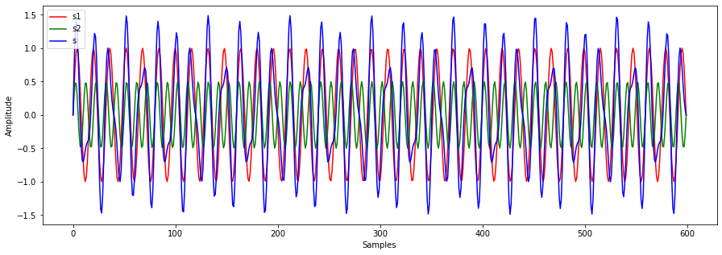

```python
plt.figure(figsize = (15, 5))
plt.plot(s1, label = 's1', color = 'r')
plt.plot(s2, label = 's2', color = 'g')
plt.plot(s, label = 's', color = 'b')
plt.xlabel('Samples')
plt.ylabel('Amplitude')
plt.legend(loc = "upper left")
```

It can be seen clearly that s(t) is formed by two sinusoidal signals s1(t) and s2(t) of different frequencies. Thus, it is expected that the Fourier transform S of s should have two peaks corresponding to the two frequencies of s1 and s2.

### However, when we call librosa.stft, we will get a different result:

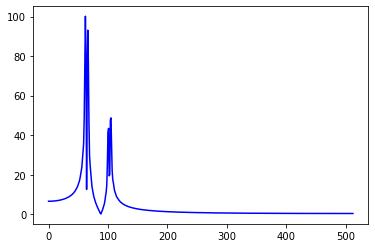

```python
S = librosa.stft(s, n_fft = 1024, window = 'hann', hop_length = N, win_length = N)
S_0 = S[:, 0]
mag_S_0 = np.abs(S_0)
plt.plot(mag_S_0, color = 'b')
```

Theoretically, the Fourier transform of a signal is defined in infinite domain. However, in this example, we apply the Fourier transform on a finite and truncated signal. To calculate the Fourier transform of truncated signals, librosa.stft uses windowing techniques. However, windowing techniques are sensitive to the borders of the truncated signals. In the above code, we set win_length=N and hop_length=N, i.e., the window fully covers the truncated signal, and this explains the situation.

To mitigate the above effects, instead of using a window fully covering the entire truncated signal, we can use a smaller window by setting win_length to a smaller value. In addition, instead of using the Fourier transform of a border frame, e.g., S_0=S[:,0],

**we can take the Fourier transform of an intermediate frame as in the code below:**

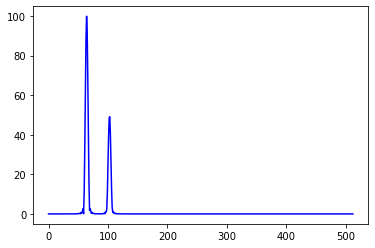

```python
#we define a window length m with less number of samples
m = 400

S = librosa.stft(s, n_fft = 1024, window = 'hann', hop_length = int(m / 2), win_length = m) #can use 'hann' or 'hamming'

#we take S_1, which is an intermediate frame.
S_1 = S[:, 1]

mag_S_1 = np.abs(S_1)
plt.plot(mag_S_1, color = 'b')
plt.savefig('hannwindow.png')
```

Different windowing techniques make different border effects. Your task is to investigate these effects by varying the parameter window in librosa.stft with options including: 'boxcar' (i.e., rectangular window), 'hann' and 'hamming', and discuss your observations.

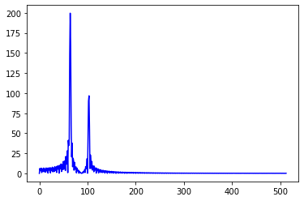

```python
#we define a window length m with less number of samples
m = 400

S2 = librosa.stft(s, n_fft = 1024, window = 'boxcar', hop_length = int(m / 2), win_length = m)
#we take S_2, which is an intermediate frame.
S_2 = S2[:, 1]

mag_S_2 = np.abs(S_2)
plt.plot(mag_S_2, color = 'b')
plt.savefig('boxcarwindow.png')
```

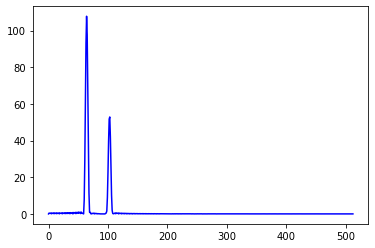

```python
#we define a window length m with less number of samples
m = 400

S3 = librosa.stft(s, n_fft = 1024, window = 'hamming', hop_length = int(m / 2), win_length = m)
#we take S_3, which is an intermediate frame.
S_3 = S3[:, 1]

mag_S_3 = np.abs(S_3)
plt.plot(mag_S_3, color = 'b')
plt.savefig('hammingwindow.png')
```

**From the above graphs for different window used for speech spectograms, we can observe that both 'hann' and 'hamming' window techniques are valid in our case as they mostly didn't introduce any noise or discontinuities at the section's boundaries and the 'Hann' window is a raised cosine window, dropping smoothly to zero at the section boundaries. This softens the artifacts in the Fourier transform of the windowed signal.**

**However, using the rectangular (Boxcar) window technique we observed some discontinuities or unwanted noise at the bounderies of our signal and has major drawbacks, since it generally leads to discontinuities at the section's boundaries. Such abrupt changes lead to artifacts due to interferences which are spread over the entire frequency spectrum. Rather than being part of the original signal, these frequency components come from the properties of the rectangular window.**

**Boxcar windows are generally used for flat spectrum and speech signals are not flat.**